# Proyecto BN

Aprendizaje Máquina II. Máster en Ciencia de Datos (UV).

Manuel Rubio Martinez y Rubén Castillo Carrasco

# 1 Objetivo

El trabajo consiste en la creación de la *Red Bayesiana* `Garaje` y realizar ejercicios de inferencia. Se hará uso de los paquetes `bnlearn` y `gRain`.

Un taller dispone de una *Red Bayesiana* para modelizar las probabilidades de su día a día. Los vehículos están caracterizados con las variables Edad (A), Tipo (T), Kilometraje (M) y si necesitan cambios de bujías (SP) y/o frenos (B)

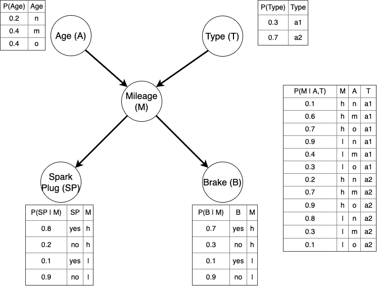

Garage

# 2 Red Bayesiana

## 2.2 Grafo Acíclico Dirigido

Creación del Grafo Acíclico Dirigido

```r
library(bnlearn)
```

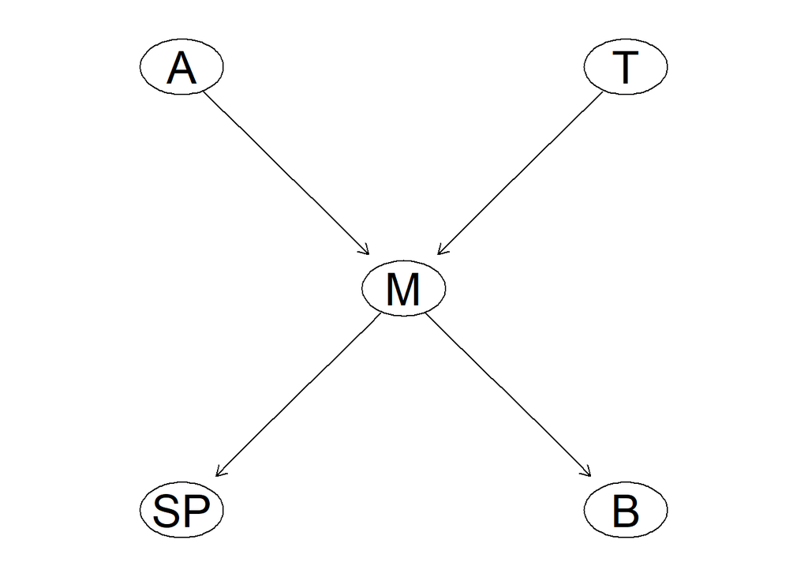

```r
dag<-empty.graph(nodes = c("A", "T", "M", "SP", "B"))

dag<-set.arc(dag,from = "A" ,to = "M")

dag<-set.arc(dag,from = "T" ,to = "M")

dag<-set.arc(dag,from = "M" ,to = "SP")

dag<-set.arc(dag,from = "M" ,to = "B")

bnlearn::graphviz.plot(dag, shape = "ellipse")
```

## 2.3 CPT, Tablas de probabilidad condicionada

Crea las matrices/arrays de probabilidad condicionada para cada nodo.

```r
A.lv <- c("n", "m", "o")
A.prob <- array(c(0.2, 0.40, 0.40), dim = 3,dimnames = list(A = A.lv))
A.prob
```

```
## A
##   n   m   o
## 0.2 0.4 0.4
```

```r
T.lv <- c("a1", "a2")
T.prob <- array(c(0.3, 0.70), dim = 2,dimnames = list(T = T.lv))
T.prob
```

```
## T
##  a1  a2
## 0.3 0.7
```

```r
M.lv <- c("h", "l")
M.prob <- array(c(0.1, 0.9, 0.6, 0.4, 0.7, 0.3, 0.2,
            0.8, 0.7, 0.3, 0.9, 0.10), dim = c(2, 3, 2),
            dimnames = list( M = M.lv, A = A.lv,T = T.lv ))


ftable(M.prob,row.vars = c(1,3))
```

```
##      A   n   m   o
## M T
## h a1   0.1 0.6 0.7
##   a2   0.2 0.7 0.9
## l a1   0.9 0.4 0.3
##   a2   0.8 0.3 0.1
```

```r
SP.lv <- c("yes","no")
SP.prob <- array(c(0.8,0.2,0.1,0.9), dim = c(2,2),dimnames = list(SP = SP.lv, M = M.lv))
ftable(SP.prob,col.vars = 1)
```

```
##   SP yes  no
## M
## h    0.8 0.2
## l    0.1 0.9
```

```r
B.lv <- c("yes", "no")
B.prob <- array(c(0.7, 0.3, 0.10, 0.9), dim = c(2, 2),
            dimnames = list(B = B.lv, M = M.lv))

ftable(B.prob,col.vars = 1)
```

```
##   B yes  no
## M
## h   0.7 0.3
## l   0.1 0.9
```

## 2.4 Red Bayesiana

Unimos el grafo y las distribuciones locales para crear la *Red Bayesiana*.

```r
cpt <- list(A = A.prob,T = T.prob,M= M.prob,SP = SP.prob,B= B.prob)
cpt
```

```
## $A
## A
##   n   m   o
## 0.2 0.4 0.4
##
## $T
## T
##  a1  a2
## 0.3 0.7
##
## $M
## , , T = a1
##
##    A
## M     n   m   o
##   h 0.1 0.6 0.7
##   l 0.9 0.4 0.3
##
## , , T = a2
##
##    A
## M     n   m   o
##   h 0.2 0.7 0.9
##   l 0.8 0.3 0.1
##
##
## $SP
##      M
## SP      h   l
##   yes 0.8 0.1
##   no  0.2 0.9
##
## $B
##      M
## B       h   l
##   yes 0.7 0.1
##   no  0.3 0.9
```

```r
bn <- custom.fit(dag, cpt)

bn
```

```
##
##   Bayesian network parameters
##
##   Parameters of node A (multinomial distribution)
##
## Conditional probability table:
##  A
##   n   m   o
## 0.2 0.4 0.4
##
##   Parameters of node T (multinomial distribution)
##
## Conditional probability table:
##  T
##  a1  a2
## 0.3 0.7
##
##   Parameters of node M (multinomial distribution)
##
## Conditional probability table:
##
## , , T = a1
##
##    A
## M     n   m   o
##   h 0.1 0.6 0.7
##   l 0.9 0.4 0.3
##
## , , T = a2
##
##    A
## M     n   m   o
##   h 0.2 0.7 0.9
##   l 0.8 0.3 0.1
##
##
##   Parameters of node SP (multinomial distribution)
##
## Conditional probability table:
##
##      M
## SP      h   l
##   yes 0.8 0.1
##   no  0.2 0.9
##
##   Parameters of node B (multinomial distribution)
##
## Conditional probability table:
##
##      M
## B       h   l
##   yes 0.7 0.1
##   no  0.3 0.9
```

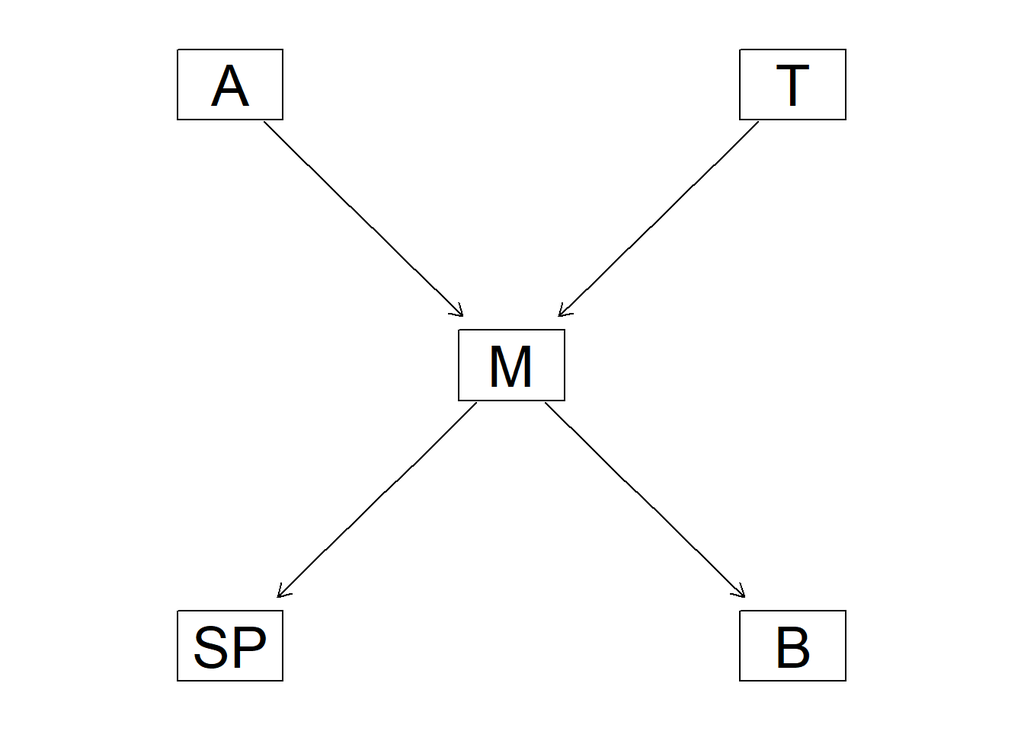

```r
graphviz.plot(bn)
```

# 3 Inferencia

## 3.1 junction tree

Crea el árbol de inferencia `junction tree` para acelerar los cálculos de las probabilidades condicionadas de manera exacta.

```r
library(gRain)
jt<-compile(as.grain(bn))
summary(jt)
```

```
## Independence network: Compiled: TRUE Propagated: FALSE
##  Nodes : Named chr [1:5] "A" "T" "M" "SP" "B"
##  - attr(*, "names")= chr [1:5] "A" "T" "M" "SP" ...
##  Number of cliques:                 3
##  Maximal clique size:               3
##  Maximal state space in cliques:   12
```

## 3.2 Razonamiento sin Evidencias

Determina las probabilidades del Kilometraje de los vehículos, $P(M)$, sin ninguna información adicional (evidencias). ¿Hay algún resultado más esperable que otro?

```r
ftable(bn$M$prob,col.vars = 1)
```

```
##      M   h   l
## A T
## n a1   0.1 0.9
##   a2   0.2 0.8
## m a1   0.6 0.4
##   a2   0.7 0.3
## o a1   0.7 0.3
##   a2   0.9 0.1
```

```r
querygrain(jt, nodes=c("M"),type="marginal") #$T
```

```
## $M
## M
##     h     l
## 0.638 0.362
```

En este caso, se obtiene que la probabilidad de que M sea alta (es decir, que el número de kilómetros sea alto) es 0.638 de no incluirse información adicional, aproximadamente dos veces mayor a ser baja, que tiene una probabilidad de 0.362.

Determina las probabilidades del Kilometraje, $M$, cuando la condicionamos al tipo, $T$. ¿observas cambios en los resultados del Kilometraje?

```r
PTR<-querygrain(jt, nodes=c("M","T"),type="conditional")
PTR
```

```
##    T
## M     a1   a2
##   h 0.54 0.68
##   l 0.46 0.32
```

Recupera la distribución de probabilidad CONJUNTA de TODAS las variables del problema. ¿cuál es la situación más probable (MAP)?

```r
PTR<-querygrain(jt, nodes=c("M","T","A","SP","B"),type="joint")
ftable(PTR)
```

```
##            B     yes      no
## A M T  SP
## n h a1 yes   0.00336 0.00144
##        no    0.00084 0.00036
##     a2 yes   0.01568 0.00672
##        no    0.00392 0.00168
##   l a1 yes   0.00054 0.00486
##        no    0.00486 0.04374
##     a2 yes   0.00112 0.01008
##        no    0.01008 0.09072
## m h a1 yes   0.04032 0.01728
##        no    0.01008 0.00432
##     a2 yes   0.10976 0.04704
##        no    0.02744 0.01176
##   l a1 yes   0.00048 0.00432
##        no    0.00432 0.03888
##     a2 yes   0.00084 0.00756
##        no    0.00756 0.06804
## o h a1 yes   0.04704 0.02016
##        no    0.01176 0.00504
##     a2 yes   0.14112 0.06048
##        no    0.03528 0.01512
##   l a1 yes   0.00036 0.00324
##        no    0.00324 0.02916
##     a2 yes   0.00028 0.00252
##        no    0.00252 0.02268
```

```r
max_valor <- max(PTR)

# Encontrar las coordenadas (índices) del valor máximo
coord_max_valor <- which(PTR == max_valor, arr.ind = TRUE)

# Obtener las etiquetas correspondientes a las coordenadas del valor máximo
val_A <- dimnames(PTR)[[1]][coord_max_valor[, 1]]
val_M <- dimnames(PTR)[[2]][coord_max_valor[, 2]]
val_T <- dimnames(PTR)[[3]][coord_max_valor[, 3]]
val_SP<-dimnames(PTR)[[4]][coord_max_valor[, 4]]
val_B<-dimnames(PTR)[[5]][coord_max_valor[, 5]]


# Imprimir el valor máximo y sus correspondientes categorías
cat(" Valor máximo:", max_valor, "\n")
```

```
##  Valor máximo: 0.14112
```

```r
cat(" Edad:",val_A, "\n",
    "Cantidad de millas:",val_M , "\n",
    "Tipo:",val_T, "\n",
    "Bujías:",val_SP, "\n",
    "Frenos:",val_B, "\n")
```

```
##  Edad: o
##  Cantidad de millas: h
##  Tipo: a2
##  Bujías: yes
##  Frenos: yes
```

En este caso se observa que el máximo de la probabilidad conjunta, 0.14112, ocurre cuando el vehículo es de tipo a2, necesita cambio de bujías (SP = yes), necesita cambio de frenos (O = yes), es antiguo (A = o) y tiene un kilometraje alto (M = h).

## 3.3 Razonamiento con Evidencias

Determina la probabilidad de la evidencia E={A=n,T=a2,M=l,SP=yes,B=yes}. Interpreta el resultado. *Nota: no es probabilidad marginal.*

```r
dimensiones <- names(dimnames(PTR))

cat("Las dimensiones del array son: ",dimensiones, "\n")
```

```
## Las dimensiones del array son:  A M T SP B
```

```r
PTR["n","l","a2","yes","yes"]
```

```
## [1] 0.00112
```

Se tiene que la probabilidad conjunta de la evidencia dada es de 0.00112.

Determina cómo se modifica la probabilidad de cambiar los frenos, $B=yes$, si sabemos que el vehículo es viejo, $A=o$. ¿Aumenta o disminuye? ¿(según las diapositivas de clase) es razonamiento evidencial o causal?

```r
PB <- querygrain(jt,node=c("B"),type="joint")
cat("La probabilidad de B es", sep = "\n")
```

```
## La probabilidad de B es
```

```r
print(PB)
```

```
## B
##    yes     no
## 0.4828 0.5172
```

```r
jt_A_old<-setEvidence(jt,node="A",states="o")

PB_A <- querygrain(jt_A_old,node=c("B"),type="joint")

cat("\nLa probabilidad de B sabiendo A = old es:",sep = "\n")
```

```
##
## La probabilidad de B sabiendo A = old es:
```

```r
print(PB_A)
```

```
## B
##   yes    no
## 0.604 0.396
```

Al saber que A = old, la probabilidad de B = yes aumenta, como se puede observar en las tablas superiores. En este caso estamos ante razonamiento causal, ya que se parte de las causas, en este caso la edad del coche, para inferir la probabilidad de las consecuencias (estado de los frenos).

Determina cómo se modifica la probabilidad de que el vehículo es nuevo, $A=n$, cuando sabemos que necesita un cambio de bujías y de frenos, $SP=yes, B=yes$. ¿(según las diapositivas de clase) es razonamiento evidencial o causal?

```r
PB <- querygrain(jt,node=c("A"),type="joint")
cat("Se tiene que la probabilidad de A es", sep = "\n")
```

```
## Se tiene que la probabilidad de A es
```

```r
print(PB)
```

```
## A
##   n   m   o
## 0.2 0.4 0.4
```

```r
jt_SP_yes<-setEvidence(jt,node="SP",states="yes")

jt_SP_yes_b_yes<-setEvidence(jt_SP_yes,node="B",states="yes")

PA_SP_B <- querygrain(jt_SP_yes_b_yes,node=c("A"),type="joint")

cat("\nLa probabilidad de A sabiendo SP y B = yes es:",sep = "\n")
```

```
##
## La probabilidad de A sabiendo SP y B = yes es:
```

```r
print(PA_SP_B)
```

```
## A
##          n          m          o
## 0.05735661 0.41950679 0.52313660
```

```r
cat("",sep = "\n")
```

En este caso, es la probabilidad de A = n la que decrementa de saberse que SP y B = yes, algo lógico al ser más probable que un coche no sea nuevo de presentar problemas en bujias y frenos. Al mismo tiempo, la probabilidad de que sea A = o (viejo) aumenta, y la de tener una edad intermedia se mantiene. Estamos ante un caso de razonamiento diagnóstico, ya que se apoya en las consecuencias, el estado de los frenos y bujías, para inferir la causa, en este caso la edad del coche.

```r
PA_H_and_T <- querygrain(jt,node=c("A","T"),type="conditional")
cat("La probabilidad conjunta de A y T es", sep = "\n")
```

```
## La probabilidad conjunta de A y T es
```

```r
print(PA_H_and_T)
```

```
##    T
## A    a1  a2
##   n 0.2 0.2
##   m 0.4 0.4
##   o 0.4 0.4
```

```r
jt_M_h<-setEvidence(jt,node="M",states="h")

PA_H_and_T_M_h <- querygrain(jt_M_h,node=c("A","T"),type="conditional")

cat("\nLa probabilidad de A y T sabiendo M = high es:",sep = "\n")
```

```
##
## La probabilidad de A y T sabiendo M = high es:
```

```r
print(PA_H_and_T_M_h)
```

```
##    T
## A           a1         a2
##   n 0.03703704 0.05882353
##   m 0.44444444 0.41176471
##   o 0.51851852 0.52941176
```

```r
cat("",sep = "\n")
```

Con las probabilidades marginales vemos que antes de conocer el kilometraje, para ambos tipos las probabilidades eran iguales, y después de conocerlo, en ambos la probabilidad de ser nuevo baja, la de ser de edad mediana sube ligeramente, y la de ser viejo sube más de un 0.1 de probabilidad marginal.